# Combined assembly VAR Transcript DE Analysis

Gerry Tonkin-Hill

22/10/2015

### Load Libraries

```r
library(limma)
library(edgeR)
library(DESeq2)
library(genefilter)
library(EDASeq)
library(RColorBrewer)
library(VennDiagram)
library(knitr)
library(reshape2)

library(pheatmap)
library(dynamicTreeCut)
library(moduleColor)
library(ggplot2)

wd = "./"
colors <- c("#0571b0", "#ca0020")
```

### Load Data

We load the read counts from the all gene analysis as well as the resulting design matrix. We also aligned each sample to a reference which included human, non-VAR falciparum, non-VAR vivax and our VAR gene transcripts from the combined sample assembly. Read counts that aligned to our transcripts were then retrieved. We use the previous all gene counts to achieve better estimates of the dispersion parameters in our model.

```r
setwd(wd)
load("./data/geneWithoutVivax_and_VARgene_countDB_subread_uH.RData")
var_gene_names <- read.delim("./data/var_gene_names.txt")
var_gene_names <- var_gene_names$X.Gene.ID.
# Load Non-var_genes
fc2 <- fc_genes_aligned_w_Pfhuman_withoutVivax
t <- fc2$counts

# Rename samples to something more sensible colnames(t) <-
# gsub('alignment\\.sam','',colnames(t)) colnames(t) <-
# gsub('.*vivax\\.','',colnames(t)) colnames(t) <- gsub('_S.*','',
# colnames(t))
nonVar <- t
nonVar.annot <- fc2$annotation

var <- var_counts$counts
var.annot <- var_counts$annotation
# colnames(var) <- gsub('.*alignments\\.','',colnames(var)) colnames(var)
# <- gsub('alignment.sam','',colnames(var)) colnames(var) <- gsub('_L00.*',
# '', colnames(var)) colnames(var) <- gsub('_S.*', '', colnames(var))
var_names <- rownames(var)

stopifnot(colnames(var) == colnames(nonVar))
combined_counts <- rbind(nonVar, var)
combined_annot <- rbind(nonVar.annot, var.annot)
```

Again we remove samples SFD1, SFM9 and SFC.025 as they were not sequenced to a sufficient depth.

```r
combined_counts <- combined_counts[, !(colnames(combined_counts) %in% c("SFD1.CM",
    "SFM9", "SFC.025"))]
```

### Filter Low Count Genes

```r
stopifnot(rownames(combined_counts) == combined_annot$GeneID)
dge <- DGEList(counts = combined_counts, genes = combined_annot)
dge_combined <- dge

cpm(10, mean(dge_combined$samples$lib.size))
```

```
##        [,1]
## [1,] 1.2068
```

```r
keep <- rowSums(cpm(dge) > 1) >= 5
dge <- dge[keep, , keep.lib.sizes = FALSE]

categories <- as.factor(substring(colnames(combined_counts), 1, 1))

modRUV <- modRUV[match(colnames(dge), rownames(modRUV)), ]
stopifnot(colnames(dge) == rownames(modRUV))
```

### All Gene PCA

To enable a comparison a plot of the all gene PCA is given. Note that this is slightly different to the one in the all gene analysis due to the less stringent filter.

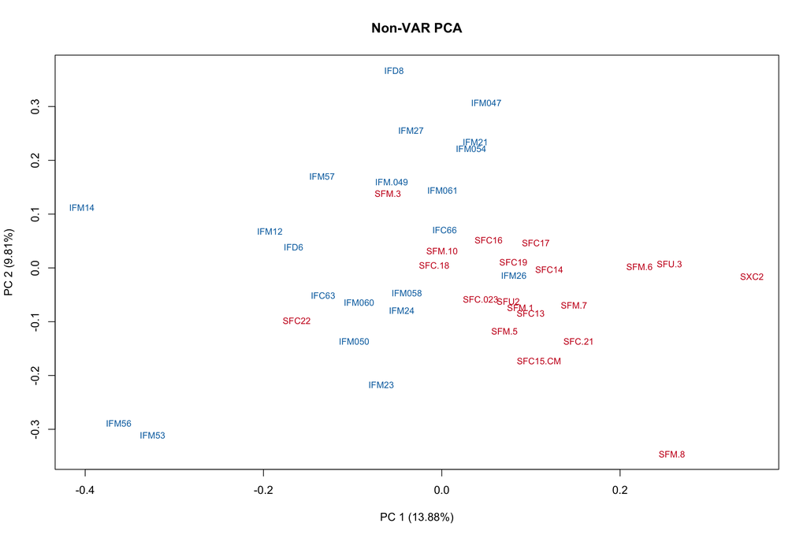

```r
categories <- as.factor(substring(rownames(dge$samples), 1, 1))
dge <- calcNormFactors(dge, method = "TMM")
dge$samples$group <- categories
design <- model.matrix(~group, data = dge$samples)

v <- voom(dge, design = design, plot = FALSE)

norm_counts_ring_ruv <- removeBatchEffect(v$E, covariates = modRUV[, 3:ncol(modRUV)],
    design = modRUV[, 1:2])
plotPCA(norm_counts_ring_ruv[!(rownames(norm_counts_ring_ruv) %in% c(var_gene_names,
    var_names)), ], col = colors[categories], cex = 0.8, isLog = TRUE)
title("Non-VAR PCA")
```

### VAR Transcript PCA (normalised for Ring and RUV-4 factors)

The remaining VAR gene transcripts are investigated in the following PCA plot. Interestingly we can see that although the non-severe samples are very spread out, the severe samples remain close together. This suggested that there is something in common in the VAR gene expression profiles of the severe samples. Exactly what produces this grouping is not clear from this PCA and further investigation is given later. However the grouping is consistent with the immune response we see in human populations where by people become immune to severe forms of malaria relatively quickly but take much longer to develop immunity to non-severe forms.

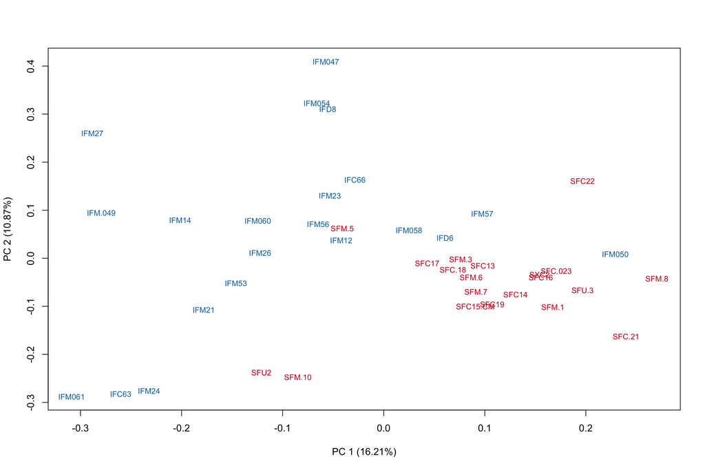

```r
plotPCA(norm_counts_ring_ruv[rownames(norm_counts_ring_ruv) %in% var_names,
    ], col = colors[categories], cex = 0.8, isLog = TRUE)
```

### VAR Transcript PCA (only normalised for library size)

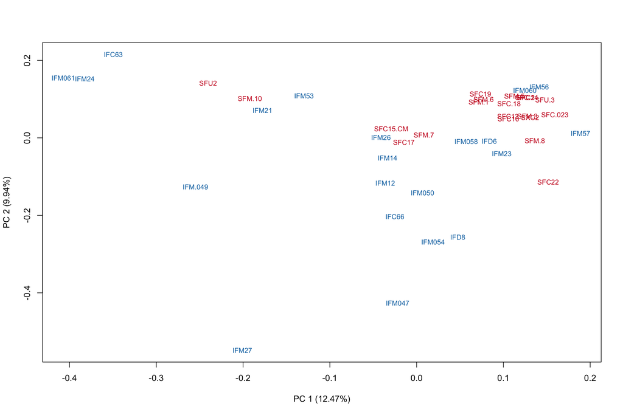

```r
plotPCA(cpm(dge, normalized.lib.sizes = TRUE, log = T, prior.count = 1)[rownames(dge) %in%
    var_names, ], col = colors[categories], cex = 0.8, isLog = TRUE)
```

### Voom Analysis (including RUV-4 and Ring factors)

Initially we performed the analysis using the same approach as the all gene analysis. After running Voom the adjusted p-values for the VAR gene transcripts were then recalculated using the Benjamini-Hochberg approach, only taking into account the VAR transcripts.

```r
stopifnot(colnames(dge) == rownames(modRUV))
v2 <- voom(dge, design = modRUV, plot = F)
fit <- lmFit(v2, modRUV)
fit <- eBayes(fit)
deVoom <- decideTests(fit, adjust.method = "BH", p.value = 0.05)

top_ring_ruv <- topTable(fit, coef = 2, p.value = 1, sort.by = "p", number = Inf,
    adjust.method = "none", confint = TRUE)
top_ring_ruv_var <- top_ring_ruv[rownames(top_ring_ruv) %in% var_names, ]
top_ring_ruv_var$adj.P.Val <- p.adjust(top_ring_ruv_var$adj.P.Val, method = "BH")
top_ring_ruv_var <- top_ring_ruv_var[top_ring_ruv_var$adj.P.Val <= 0.05, ]

voomUp <- rownames(top_ring_ruv_var[top_ring_ruv_var$logFC > 0, ])
voomDown <- rownames(top_ring_ruv_var[top_ring_ruv_var$logFC < 0, ])
voomUpDown <- c(voomUp, voomDown)
```

### DESeq2 Analysis (simplified design matrix)

In order to achieve a higher sensitivity we looked at the VAR gene transcripts using DESeq2 ignoring the Ring and RUV-4 factors. Note that we used the default DESeq2 pipeline for this analysis. This included using DESeq2 to filter out genes with low expression. It’s default filter was less stringent to the one used in the voom analysis. Unlike the voom approach, only the VAR gene counts were used in this analysis. This reduced any dependancy that life-cycle might play on overall VAR expression and increased the sensitivity of the analysis. This approach is likely to have a higher FDR however in this case we are interested in identifying a larger number of VAR genes for further biological analysis.

```r
colData <- data.frame(disease = as.factor(substring(rownames(dge_combined$samples),
    1, 1)))
rownames(colData) <- rownames(dge_combined$samples)
dds <- DESeqDataSetFromMatrix(countData = dge_combined$counts[rownames(dge_combined) %in%
    var_names, ], colData = colData, design = ~disease)
dds <- estimateSizeFactors(dds)
dds <- DESeq(dds)
res <- results(dds, contrast = c("disease", "S", "I"))

resVar <- res[rownames(res) %in% var_names, ]
simpleDE_resVar <- data.frame(resVar)
resOrdered <- resVar
resOrdered <- resOrdered[!is.na(resOrdered$padj), ]
resOrdered <- resOrdered[resOrdered$padj < 0.05, ]
```

A summary of the DESeq2 analysis on the VAR gene transcripts is given below.

```r
summary(resVar, alpha = 0.05)
```

```
##
## out of 3214 with nonzero total read count
## adjusted p-value < 0.05
## LFC > 0 (up)     : 17, 0.53%
## LFC < 0 (down)   : 36, 1.1%
## outliers [1]     : 0, 0%
## low counts [2]   : 2239, 70%
## (mean count < 1)
## [1] see 'cooksCutoff' argument of ?results
## [2] see 'independentFiltering' argument of ?results
```

Genes identified as significantly differentially expressed are then grouped according to LFC.

```r
de_varOnlyGenesUpDown <- rownames(resOrdered)

resUp <- resOrdered[resOrdered$log2FoldChange > 0, ]
resDown <- resOrdered[resOrdered$log2FoldChange < 0, ]
DESeqUp <- rownames(resUp)
DESeqDown <- rownames(resDown)
DESeqUpDown <- c(DESeqUp, DESeqDown)
```

## Heatmap of up-regulated segment clusters

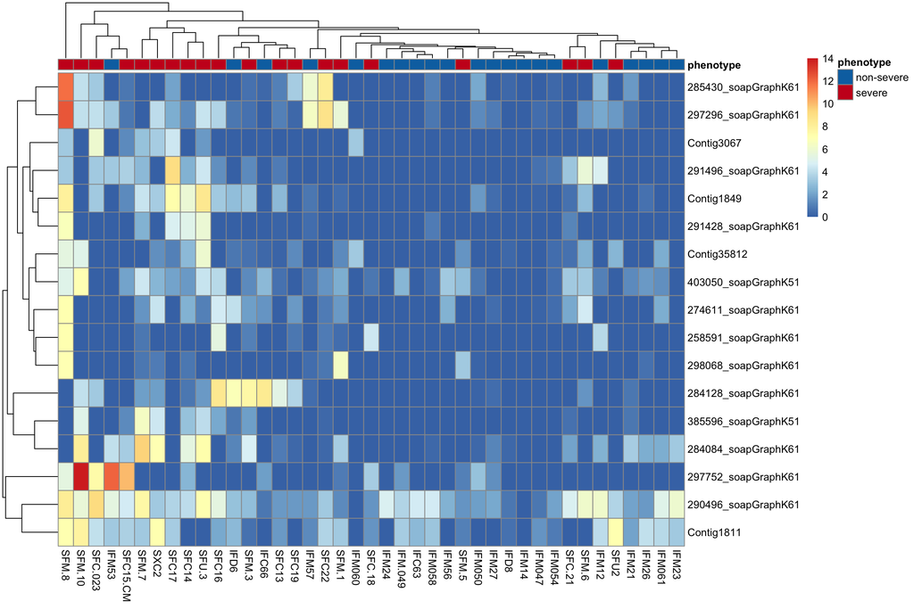

```r
setwd(wd)


select <- order(rowMeans(counts(dds, normalized = TRUE)), decreasing = TRUE)

nt <- normTransform(dds)
log2.norm.counts <- assay(nt)[select, ]
log2.norm.counts <- assay(nt)[rownames(nt) %in% rownames(resUp), ]
# log2.norm.counts <- log2.norm.counts[,colData$disease=='S']
annotData <- colData

disease <- colors
names(disease) <- c("non-severe", "severe")
anno_colors <- list(phenotype = disease)
annotData$phenotype[annotData$disease == "I"] <- "non-severe"
annotData$phenotype[annotData$disease == "S"] <- "severe"
# annotData <- annotData[annotData$disease=='S',]
annotData$disease <- NULL
pheatmap(log2.norm.counts, cluster_rows = TRUE, show_rownames = T, cluster_cols = TRUE,
    annotation_col = annotData, annotation_colors = anno_colors)
```

## Heatmap of down-regulated segment clusters

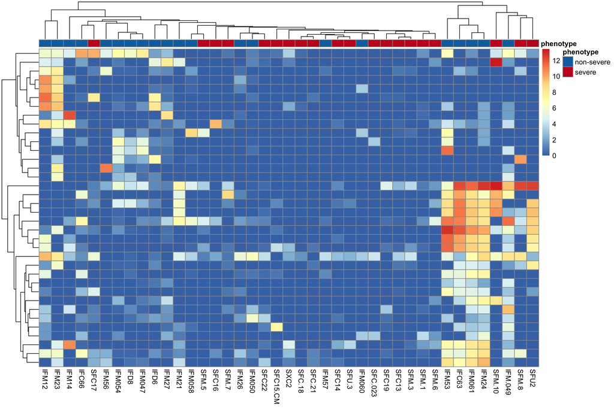

```r
setwd(wd)

select <- order(rowMeans(counts(dds, normalized = TRUE)), decreasing = TRUE)

nt <- normTransform(dds)
log2.norm.counts <- assay(nt)[select, ]
log2.norm.counts <- assay(nt)[rownames(nt) %in% rownames(resDown), ]
# log2.norm.counts <- log2.norm.counts[,colData$disease=='S']
annotData <- colData

disease <- colors
names(disease) <- c("non-severe", "severe")
anno_colors <- list(phenotype = disease)
annotData$phenotype[annotData$disease == "I"] <- "non-severe"
annotData$phenotype[annotData$disease == "S"] <- "severe"
# annotData <- annotData[annotData$disease=='S',]
annotData$disease <- NULL
pheatmap(log2.norm.counts, cluster_rows = TRUE, show_rownames = FALSE, cluster_cols = TRUE,
    annotation_col = annotData, annotation_colors = anno_colors)
```

# DESeq2 Transcript Results

```r
# Now print the table
resVar$pvalue <- format(resVar$pvalue, scientific = TRUE, digits = 3)
resVar$padj <- format(resVar$padj, scientific = TRUE, digits = 3)
kable(resVar, digits = 3)
```

|  | baseMean | log2FoldChange | lfcSE | stat | pvalue | padj |
| --- | --- | --- | --- | --- | --- | --- |
| Contig10660 | 0.549 | 0.682 | 2.111 | 0.323 | 7.47e-01 | NA |
| Contig11136 | 2.028 | -1.094 | 1.985 | -0.551 | 5.82e-01 | 7.78e-01 |
| 737460_soapGraphK31 | 0.000 | NA | NA | NA | NA | NA |
| 283924_soapGraphK61 | 5.294 | -0.445 | 1.396 | -0.319 | 7.50e-01 | 8.76e-01 |
| 531897_soapGraphK41 | 7.588 | 2.403 | 1.100 | 2.185 | 2.89e-02 | 1.69e-01 |
| 541941_soapGraphK41 | 0.283 | 2.528 | 2.236 | 1.131 | 2.58e-01 | NA |
| 276485_soapGraphK61 | 0.602 | 2.955 | 1.774 | 1.666 | 9.58e-02 | NA |
| 532711_soapGraphK41 | 0.868 | 2.408 | 1.872 | 1.286 | 1.98e-01 | NA |
| 298426_soapGraphK61 | 0.464 | -0.038 | 1.800 | -0.021 | 9.83e-01 | NA |
| 291638_soapGraphK61 | 0.197 | 1.232 | 2.027 | 0.608 | 5.43e-01 | NA |
| 400902_soapGraphK51 | 0.016 | -0.069 | 2.270 | -0.031 | 9.76e-01 | NA |
| 399908_soapGraphK51 | 8.364 | 1.177 | 1.470 | 0.800 | 4.24e-01 | 6.68e-01 |
| 279935_soapGraphK61 | 4.922 | 0.721 | 1.889 | 0.382 | 7.03e-01 | 8.44e-01 |
| 263121_soapGraphK61 | 0.535 | -0.554 | 1.266 | -0.437 | 6.62e-01 | NA |
| 396232_soapGraphK51 | 0.485 | 3.110 | 2.138 | 1.455 | 1.46e-01 | NA |
| 277905_soapGraphK61 | 0.066 | 0.215 | 2.267 | 0.095 | 9.24e-01 | NA |
| 374200_soapGraphK51 | 0.000 | 0.000 | 0.000 | 0.000 | 1.00e+00 | NA |
| 394994_soapGraphK51 | 0.316 | 1.939 | 1.775 | 1.092 | 2.75e-01 | NA |
| 285498_soapGraphK61 | 0.083 | -1.505 | 1.828 | -0.823 | 4.10e-01 | NA |
| 386742_soapGraphK51 | 0.302 | 1.562 | 1.674 | 0.933 | 3.51e-01 | NA |
| 279911_soapGraphK61 | 0.352 | -1.776 | 1.813 | -0.980 | 3.27e-01 | NA |
| 259213_soapGraphK61 | 13.151 | 0.483 | 1.698 | 0.284 | 7.76e-01 | 8.92e-01 |
| 268187_soapGraphK61 | 0.076 | -1.311 | 2.265 | -0.579 | 5.63e-01 | NA |
| Contig6616 | 0.025 | 0.462 | 2.270 | 0.204 | 8.39e-01 | NA |
| 389092_soapGraphK51 | 0.003 | -0.304 | 2.276 | -0.133 | 8.94e-01 | NA |
| 292428_soapGraphK61 | 2.796 | -2.752 | 0.990 | -2.779 | 5.46e-03 | 7.65e-02 |
| Contig10468 | 1.601 | 1.447 | 1.653 | 0.875 | 3.81e-01 | 6.22e-01 |
| 723459_soapGraphK31 | 0.052 | 1.092 | 2.260 | 0.483 | 6.29e-01 | NA |
| Contig11337 | 0.603 | -3.340 | 2.243 | -1.489 | 1.36e-01 | NA |
| Contig11335 | 0.886 | 3.947 | 2.002 | 1.972 | 4.87e-02 | NA |

[output cut: 3442 more lines]